# Análise de personalidade do cliente

Gleynner Ghiotto

# 1 Demonstração do problema:

A análise de personalidade do cliente tem a finalidade de encontrar os clientes ideais de uma empresa. Essa análise ajuda a empresa a entender melhor os seus clientes e facilita a modificação de produtos de acordo com suas necessidades, comportamentos e preocupações específicas.

Por exemplo, em vez de uma empresa gastar dinheiro para comercializar um novo produto para cada cliente do banco de dados, ela pode analisar qual segmento de cliente tem mais probabilidade de comprar determinado produto e comercializá-lo apenas para esses clientes-alvo.

Visto os benefícios desta aplicação (como a redução de custos e potencialização de campanhas), deseja-se realizar uma análise de agrupamento para resumir os segmentos de clientes existentes nessa empresa.

# 2 Análise exploratória

Fazendo uso da base de dados disponível no Kaggle ([link](https://www.kaggle.com/datasets/imakash3011/customer-personality-analysis)), o processo de análise foi iniciado fazendo uma investigação com o intuito de compreender melhor o que é tratado em cada item e, também, verificar a possibilidade de encontrar valores que possam causar problemas às análises, como valores ausentes e/ou inconsistentes. Esta verificação possibilita o tratamento adequado dos dados.

## 2.1 Análise univariada

Nessa etapa foi verificado que o conjunto de dados é formado, inicialmente, por 29 variáveis contendo informações de 2240 clientes (isso para o conjunto de dados em sua forma bruta). Ao investigar a presença de valores ausentes, foi detectado que a variável **Income** (renda familiar anual) contém 24 observações faltando esta informação. Foi observado ainda que, as variáveis **Z_CostContact** e **Z_Revenue** possuem o mesmo valor em todas as observações, logo, elas não contribuem para as análises estatísticas e construção de modelos.

A variável **Year_Birth**, ano de nascimento do cliente, foi utilizada para calcular suas respectivas idades, sendo que os clientes nasceram entre o anos de 1.893 e 1.996. Após calculado as **idades**, foi verificado que existem clientes com idade variando desde 26 até 129 anos, conforme mostra o boxplot da figura 01.

**Figura 01:** distribuição dos valores da variável Idade.

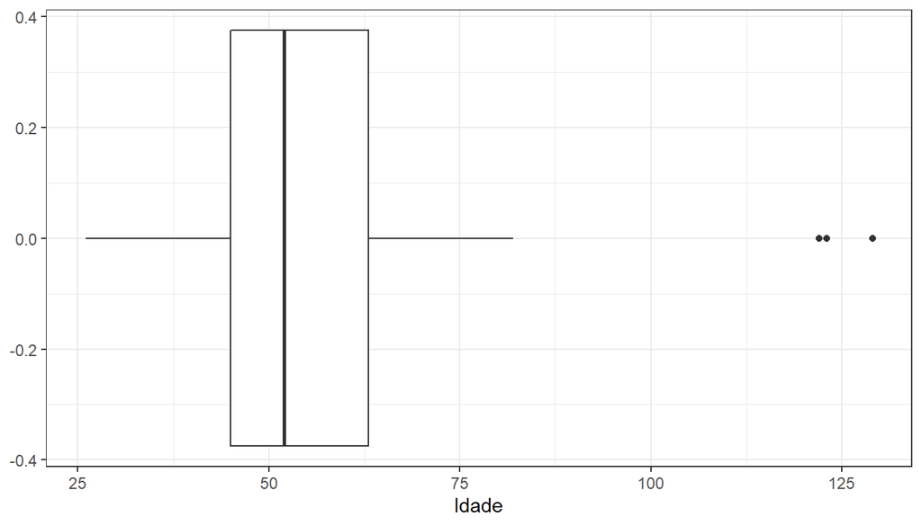

Ao observar a figura acima foi identificado a presença de pessoas com idade muito acima do que os demais clientes e, desta forma, as idades com valores discrepantes (isto é, idades maiores do que 120 anos) foram eliminadas, permanecendo apenas os clientes com idades variando entre 26 e 82 anos. As dez idades mais frequentes entre os clientes desse mercado são mostradas na tabela abaixo:

**Tabela 01:** quadro de idades mais frequentes.

| Idade | Frequência |
| --- | --- |
| 46 | 89 |
| 51 | 86 |
| 47 | 83 |
| 50 | 78 |
| 44 | 76 |
| 52 | 75 |
| 57 | 74 |
| 49 | 72 |
| 53 | 70 |
| 48 | 69 |

Para a variável **Education** (nível educaional) foram realizadas as seguintes classificações: as categorias “Basic” e “2n Cycle” tiveram classificação “Undergraduate” e as categorias “Graduation”, “Master” e “PhD” foram classificadas como “Postgraduate”. Procedimento similar foi feito para a variável **Marital_Status** (estado civil), onde as categorias “Single”, “Divorced”, “Absurd”, “Widow” e “YOLO” foram classificadas como “Alone” e as categorias “Married” e “Together” foram classificadas como “In couple”. Na figura 02 é possível fazer um comparativo entre a quantidade de cada classe, em ambos os casos, e notar que um grande percentual dos clientes possui pelo menos o nível superior e que 64,57% são casados.

**Figura 02:** (a) quantidade de clientes por nível educacional; (b) quantidade de clientes por estado civil.

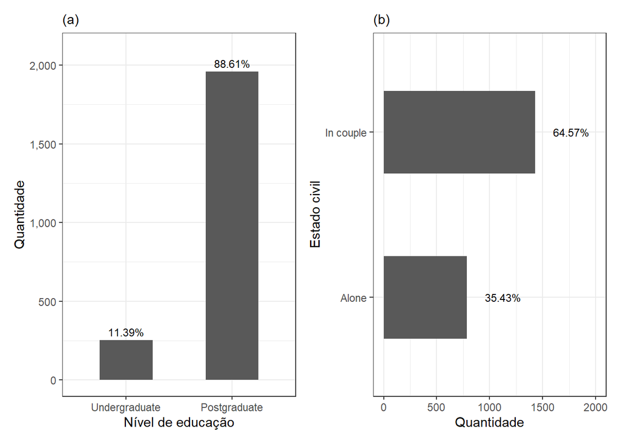

Fazendo uma análise mais detalhada da variável **Income** foi verificado a presença de um valor de renda anual muito elevado quando comparado aos demais clientes. Este valor de renda anual igual a 666.666,00 unidades monetária foi tratado como outlier e eliminado do conjunto de dados. Contudo, apesar de ainda restarem outros valores maiores, estes ocorrem mais vezes e possivelmente representam clientes com renda anual mais elevada. A visualização da distribuição dos valores antes e após a eliminação do valor inconsistente pode ser vista na figura a seguir:

**Figura 03:** (a) distribuição da renda anual dos clientes antes da eliminação de valores inconsistentes ; (b) distribuição da renda anual dos clientes após a eliminação de valores inconsistentes.

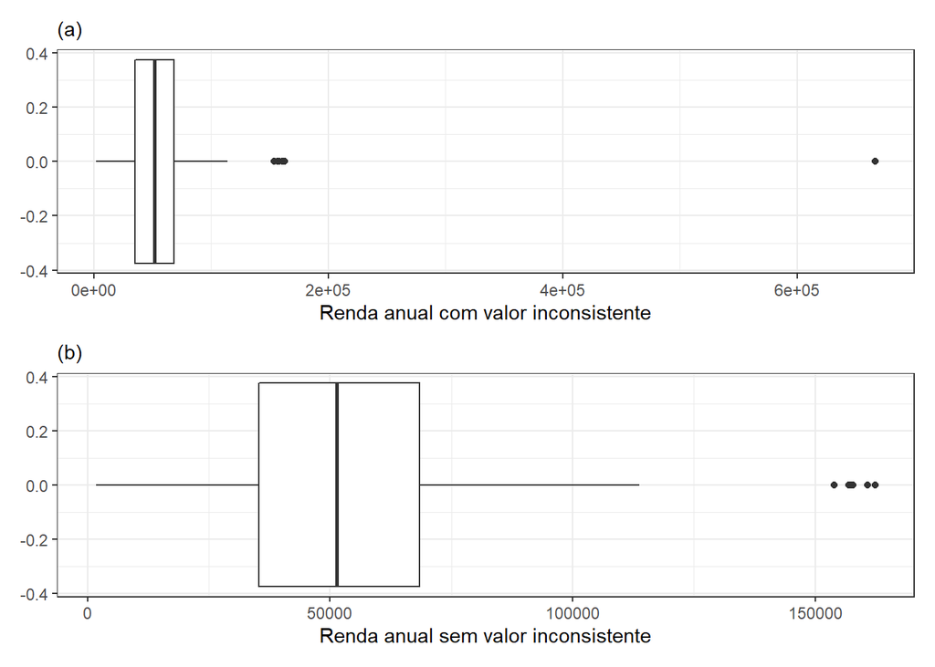

As variáveis **Kidhome** e **Teenhome** (respectivamente, o número de crianças e adolescentes na residência do cliente) foram analisadas individualmente e em seguida utilizadas para calcular o número total de filhos, encontrando-se assim, clientes que não têm nenhum filho e clientes com até 3 filhos. Conforme a figura 04, é possível observar que os clientes que possuem entre 0 e 1 filhos correspondem a mais de 75% do total de clientes desse supermercado.

**Figura 04:** percentual de clientes por número de filhos.

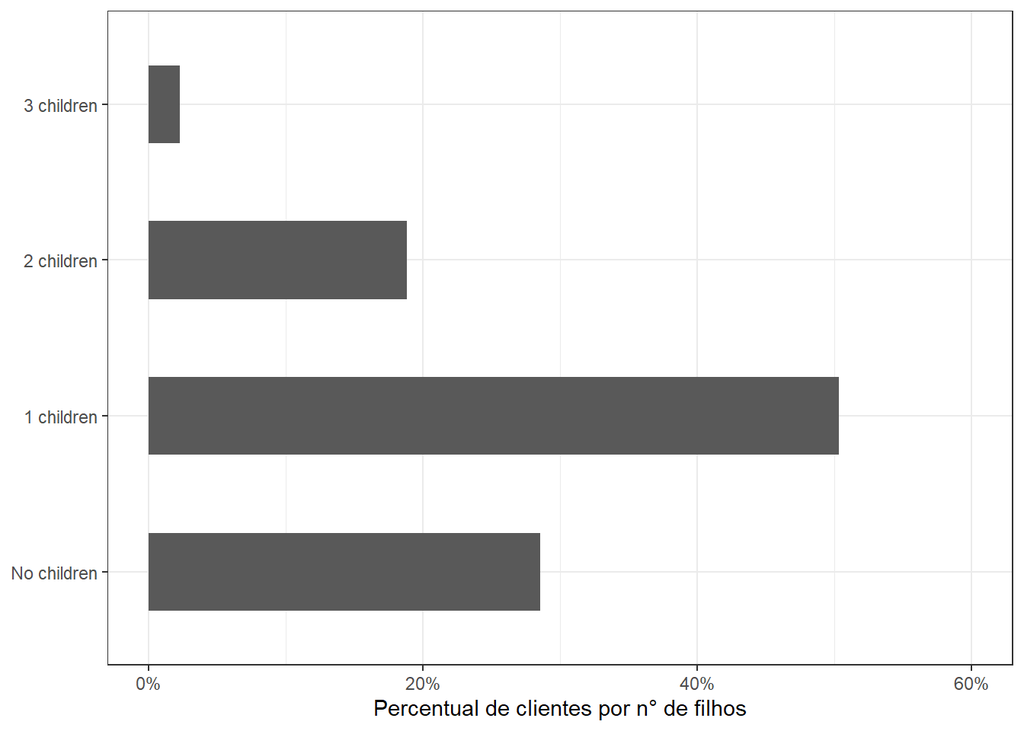

Já as variáveis **MntWines**, **MntFruits**, **MntMeatProducts**, **MntFishProducts**, **MntSweetProducts** e **MntGoldProds**, que representam o montante gasto em cada tipo de produto, foram utilizadas para obter o valor total gasto em compras nos últimos 2 anos para cada cliente do banco de dados. O gasto total em compras dos clientes é distribuído conforme mostra a figura 05, podendo-se observar que, 75% dos clientes gastam até 1.048 unidades monetária (u.m.) e que grande quantidade deles tem gastos menores (25% dos clientes gastam até 69 unidades). Os clientes deste mercado têm um gasto total médio nos últimos 2 anos igual a 607,27 e um gasto médio por compra realizada igual a 37,55 unidades monetária.

**Figura 05:** (a) boxplot do gasto em compras dos clientes; (b) histograma do gasto em compras dos clientes.

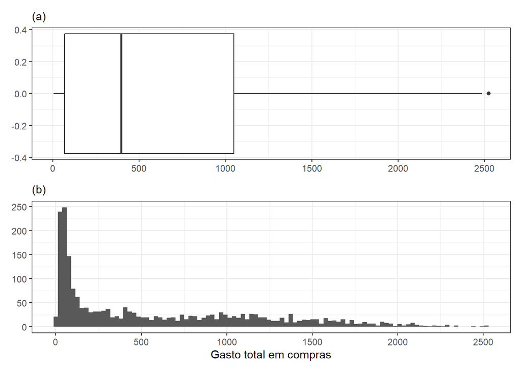

As variáveis **NumWebPurchases**, **NumCatalogPurchases** e **NumStorePurchases** foram utilizadas no cálculo do número total de compras realizadas pelos clientes, somando-se assim, o número de compras feita por meio da web, catálogo e loja física. Procedimento similar também foi feito para as variáveis **AcceptedCmp1**, **AcceptedCmp2**, **AcceptedCmp3**, **AcceptedCmp4** e **AcceptedCmp5**, contabilizando o número total de ofertas aceitas pelos clientes nas 5 campanhas. Por meio da figura 06, percebe-se que maior parte das compras são feitas por meio da loja física, seguida das compras online, e que 79,29% dos clientes não aderiram a nenhuma das campanhas.

**Figura 06:** (a) quantidade de comprada via store, web e catálogo; (b) quantidade e percentual de clientes que aderiram as campanhas.

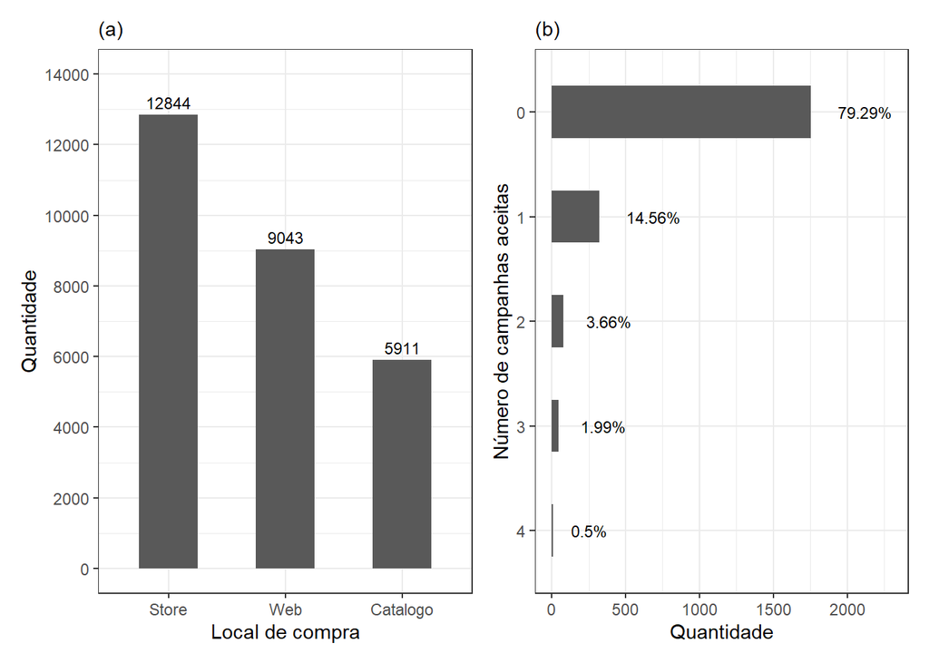

No entanto, fazendo uma visualização do gasto total em compras nos últimos 2 anos, discretizando pelo nível educacional, têm-se que pessoas pós graduadas representam 92,31% do total gasto em compras e, de forma similar, quando discretizado pelo estado civil, os casados correspondem a 63,56% desse total. Fazendo a mesma análise pelo número de filhos, observa-se que quanto mais filhos o cliente tem menos ele tendem a gastar. Esta relação pode ser vista na figura abaixo:

**Figura 07:** (a) gasto em compras por nível educaional; (b) gasto em compras por estado civil; (c) gasto em compras por número de filhos.

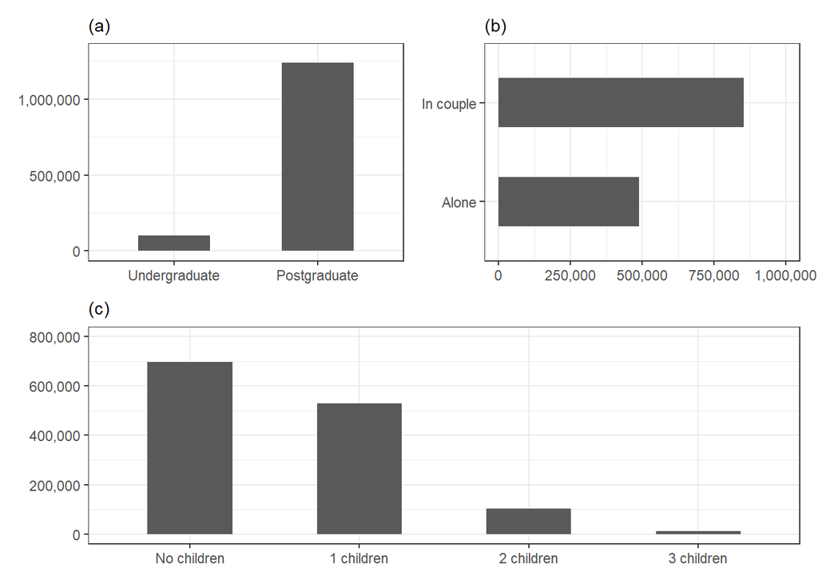

## 2.2 Análise bivariada

Analisando a relação entre a renda anual e o valor médio por compra, na figura 08 (a), observa-se que os clientes que mais gastam tendem a ter renda anual variando entre 50000 e 100000 por ano, valendo ressaltar que os “Postgraduate” possuem conjunto de pontos tendendo para valores médios de compra mais elevado quando comparado aos “Undergraduate”. Isso faz com que a média por compra para esse grupo seja maior, isto é, os pós graduados possuem média por compra de 38,9 u.m. enquanto a outra classe tem média por compra igual a 27,1 unidades. Contudo, ainda existe aquelas pessoas que ganham relativamente pouco e gastam muito.

**Figura 08:** (a) valor médio por compra em função da renda anual, discretizado por nível educacional; (b) gasto total em compras nos últimos 2 anos em função da renda anual, discretizado por número de filhos.

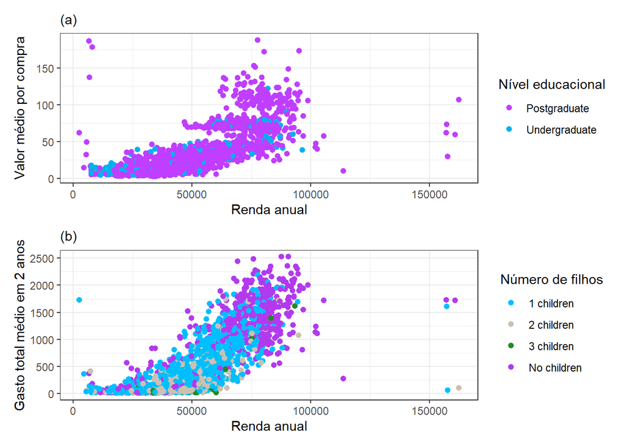

## 2.3 Correlação entre variáveis

De acordo com o quadro de correlações da figura 09, observa-se que o total gasto em compras nos 2 últimos anos tem relação direta com a renda anual, número de compras realizadas e, em proporção menor, ao número de campanhas aceitas pelo cliente. Contudo, com relação indiretamente proporcional, tem-se que quanto maior é o número de filhos menos o cliente tende a comprar. Estas e outras relações podem ser verificada na figura abaixo.

**Figura 09:** quadro de correlações entre variáveis.

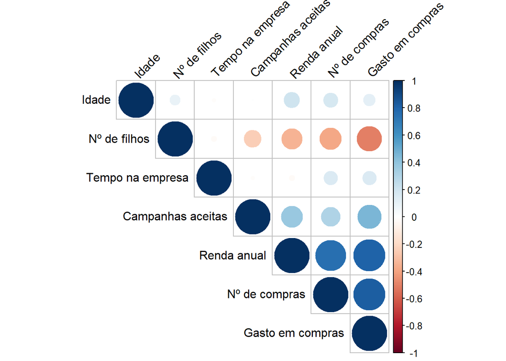

# 3 Análise de cluster

A ideia principal da Análise de Cluster é a possibilidade de classificar os objetos em grupos, de forma que, dentro de um mesmo grupo, os objetos sejam o mais similares possível e, de forma análoga, que os diversos grupos (clusters) sejam o mais diferente possível em sua constituição. Como este tipo de aprendizado de máquina é não supervisionado, não é necessário obter informações prévias sobre a composição desses grupos.

O algoritmo K-means inicializa os $k$ centroides (centro de um cluster) de modo aleatório e, para cada ponto da base de dados, calcula-se a distância Euclidiana com relação a cada um dos centroides e os associa àquele que estiver mais próximo. Após classificados os pontos de acordo com o centroide mais próximo, é calculado a média de todos os pontos contidos em cada centroide e, então, definido a posição para o novo centroide. O cálculo para este procedimento segue a equação abaixo e se repete, em diversas iterações, até que não ocorra mudança significativa com relação aos pontos e os seus respectivos centroides, isto é, a soma dos quadrados da distância de cada observação em relação ao seu cluster central é mínima.

$$W(C_k)=\sum _{x_i \in C_k}(x_i- \mu
_k)^2$$
onde $x_i$ é o ponto pertencente ao grupo $C_k$ e ${ \mu _k}$ representa a média do valor atribuído ao cluster $C_k$.

Para encontrar o número ideal de clusters é utilizado o método de Elbow. Com o uso deste método estamos variando o número de clusters ($k$) e, para cada valor de $k$, calcula-se o WCSS (Within-Cluster Sum of Square) correspondente. O WCSS é a soma da distância entre cada ponto e o seu respectivo centroide elevados ao quadrado. O valor do WCSS é maior quando $k$ é igual a um e começa a diminuir à medida que o número de clusters aumenta. Quando analisamos o gráfico gerado, podemos ver que o mesmo mudará rapidamente em um determinado ponto e, assim, assumirá a forma de cotovelo. A partir deste ponto, o gráfico começa a se mover quase paralelo ao eixo X. O valor de $k$ correspondente a este ponto é o valor ótimo do número de clusters. O WCSS é calculado conforme a seguinte equação:

$$WCSS=\sum_{k=1}^{K}
W(C_k)=\sum_{k=1}^{K}\sum _{x_i\in C_k}(x_i-\mu _k)^2$$

Observando o gráfico da figura 10, que mostra o gráfco do método de Elbow para a renda anual e o gasto total em compras do cliente nos últimos 2 anos, nota-se que existe uma maior variação do WCSS ao se passar de 1 para 2 clusters e isso faz com que ocorra uma mudança abrupta no gráfico, tornando $k$ igual a 2 o valor ótimo para o número de clusters.

**Figura 10:** método de Elbow para renda anual e o gasto total do cliente.

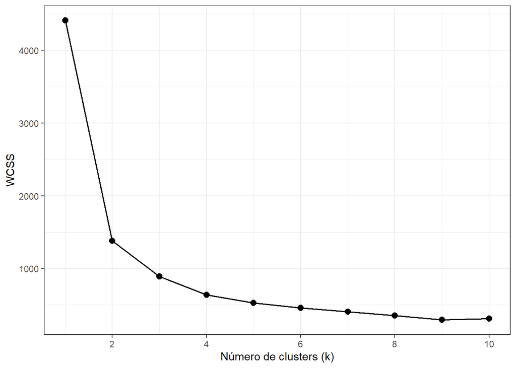

Analisando o agrupamento para o gasto total em compras em função da renda anual percebe-se a formação de dois grupos. O primeiro grupo, o cluster 1 (na cor verde), mostra os clientes que possuem renda anual inferior ao outro grupo e, desta maneira, tendem a gastar menos em compras. Estes clientes tendem a uma renda anual média igual a 37.719,58 unidades monetárias (u.m.) e gastar em compras um valor médio de 176,62. Já o cluster 2 (cor roxa), representa os clientes com melhores condições financeiras e que estão dispostos a gastar mais em compras. Estes clientes tendem a ter salários variando entre 50 e 100 mil e gastar em média 1.224,55 u.m. em compras. Esta relação pode ser melhor vista na figura 11:

**Figura 11:** análise de agrupamento para o gasto em compras em função da renda anual.

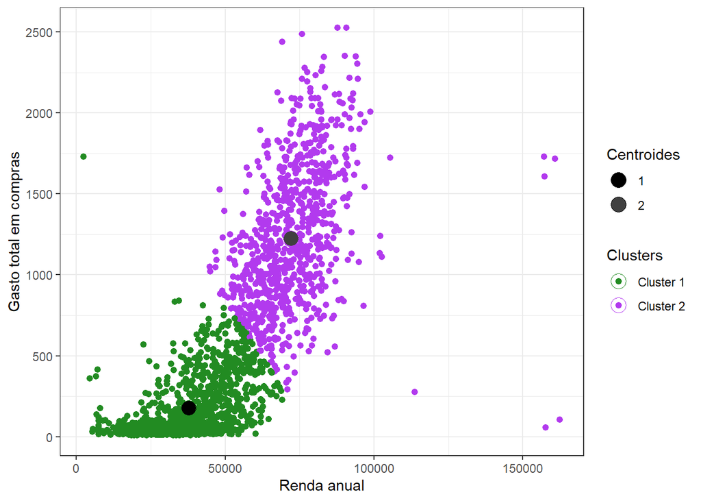

Na figura 12 (a), é mostrado a análise de agrupamento para a renda anual em função da idade e a mesma análise para o gasto total em compras em função da idade, no gráfico b. No gráfico “a”, os clientes com idade até aproximadamente 55 anos se dividem em grupos que possuem renda anual superior a 50 mil, na cor roxa, e clientes que possuem renda inferior a este valor, na cor azul. Contudo, para idade acima de 60 anos (cor verde), os clientes tendem a se dispersar para valores de renda anual até 113.734 (u.m.). Já no gráfico “b”, também há divisão em 3 grupos que se comportam de forma similar. Neste gráfico, o cluster 2 é o grupo de pessoas que mais estão dispostos a gastar enquanto o cluster 1 (cor verde) é o que menos gasta. Os circulos na cor preta, azul e cinza rempresentam os centroides dos clusters.

**Figura 12:** (a) agrupamento para a renda anual em função da idade; (b) agrupamento para gasto em compras em função da idade

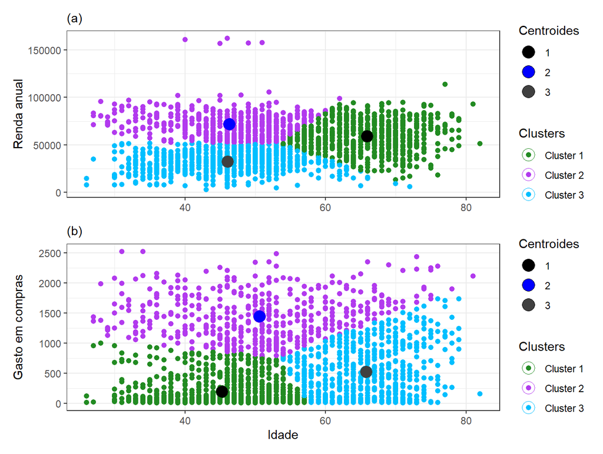